# MAE4011 - Lab 4

27th of November, 2020

# Item Bias

This document will go through how you can evaluate bias in items using sum-scores. The data used in this lab is available on Canvas, as the `dataG4G6.RData`

You can load the data into your workspace by using the `load()` function, if the data is in your working directory.

```r
load('dataG4G6.RData')
```

The data contains 6 variables from a unidimensional reading comprehension test. The results from 1000 students is included in the data, where 500 students are from grade 4, and 500 students are from grade 6.

Throughout this lab, we will use the package `lavaan`. You can install and load `lavaan` using the code below, if you haven’t already.

```r
#install.packages('lavaan')
library(lavaan)
```

## Establish measurement model.

In order to evaluate item bias, we first need to establish the appropriate measurement model to use. If the measurement models are not comparable, it is futile to evaluate item bias.

Below we estimate a single-factor model using `lavaan`, and evaluate how the model fits.

```r
#Specify single factor model
mymodel <- '
F1 =~ X1 + X2 + X3 + X4 + X5 + X6
'
#Estimate the model with maximum likelihood ("ML")
mycfa <- cfa(mymodel, data = dataG4G6[,1:6], std.lv = TRUE, estimator = "ML")
```

We can evaluate the model using the following functions:

```r
#Estimated factor loadings and error variances
coef(mycfa)
summary(mycfa)

#Various fit measures
fitMeasures(mycfa)

#Residuals based on the observed and
#model-implied correlation matrices
residuals(mycfa, "cor")
mean(residuals(mycfa, "cor")$cov)
sd(residuals(mycfa, "cor")$cov)

#Coefficient omega
sum(coef(mycfa)[1])^2 / var((dataG4G6[,1]))
sum(coef(mycfa)[2])^2 / var((dataG4G6[,2]))
sum(coef(mycfa)[3])^2 / var((dataG4G6[,3]))
sum(coef(mycfa)[4])^2 / var((dataG4G6[,4]))
sum(coef(mycfa)[5])^2 / var((dataG4G6[,5]))
sum(coef(mycfa)[6])^2 / var((dataG4G6[,6]))
sum(coef(mycfa)[1:6])^2 / var(rowSums(dataG4G6[,1:6]))
```

Note, you can also get standardized loading by using the argument `standardized=TRUE`with the `summary()` function. The column `std.all` is the standardized loadings.

### TASK: Estimate a single factor model for grade 4 and grade 6 individually. Evaluate the models.

You can split the data using the following code hidden in the spoiler:

[figure not shown]

```r
#Extract grade 4 and grade 6 data
G4 <- dataG4G6[dataG4G6$grade == "G4",1:6]
G6 <- dataG4G6[dataG4G6$grade == "G6",1:6]
```

In your model evaluation, you should include an evaluation of the model fit, the factor loadings and the reliability of the scales.

## Evaluating item bias between groups

### Evaluating group performance on items

To evaluate how two groups perform on an item, we can use a t-test, or evaluate the item visually for the two groups.

```r
t.test(G4$X6, G6$X6)
h1 <- hist(G4$X6)
```

```r
h2 <- hist(G6$X6)
```

```r
# first histogram
plot(h1,
      col=rgb(0,0,1,1/4),
      xlim=c(2,14),
      ylim = c(0,200))
# second histogram
plot(h2,
     col=rgb(1,0,0,1/4),
     xlim=c(2,15),
     ylim = c(0,200),
     add=T)             # Adds the plots together
```

[output not shown]

This methods shows you if there is difference in performance on the item for each group. It does not however condition on the underlying trait measured. As such, it is vulnerable to natural differences between the groups.

### Evaluating item bias conditioned on remainder test score

The first step when evaluating if an item is biased, is to establish a proxy for the construct the test aims to measure. A common approach is to use the remainder of the test.

```r
#Remainder scores based on scales 1 to 5
G4_X1_5 <- rowSums(G4[1:5])
G6_X1_5 <- rowSums(G6[1:5])
```

The next step is to evaluate performance conditioned on the proxy we use to represent the measured construct. You can either use bins, or mean performance for each score.

When using bins, a t-test is a suitable evaluation. Optionally, you can use a histogram to communicate it visually.

```r
#Test equality of scale 6 mean scores
#conditional on a range of remainder scores
t.test(G4$X6[G4_X1_5 > 55 & G4_X1_5 < 61],
       G6$X6[G6_X1_5 > 55 & G6_X1_5 < 61])
```

When using multiple bins, or integer scores, it is recommended to use a visual representation when communicating the results. Furthermore, this divides your data into very small groups, making a t-test less useful.

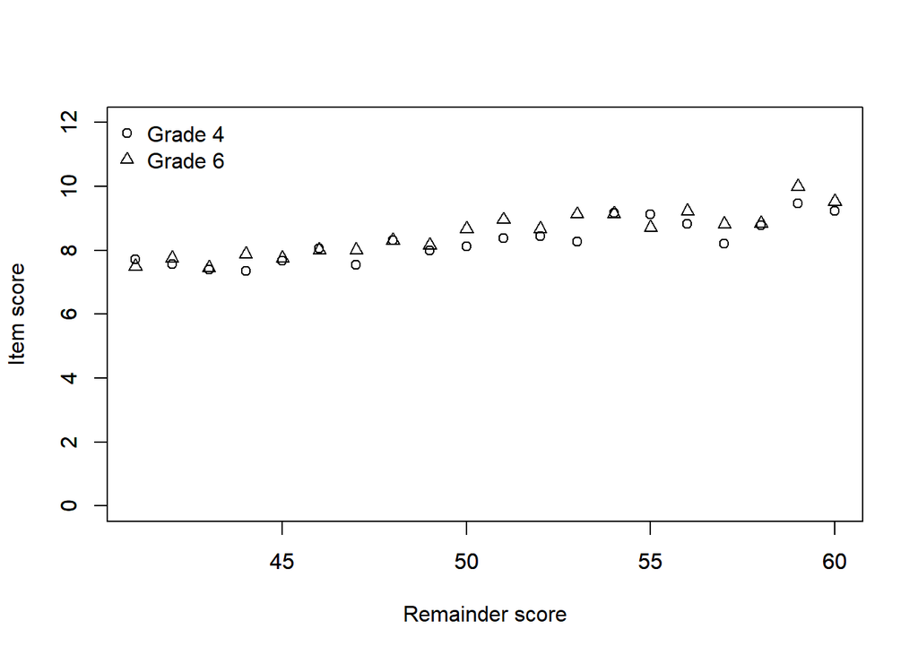

```r
#Obtain distribution of mean scale 6 scores
#conditional on particular remainder scores
G4_X6_dist <- numeric(20)
G6_X6_dist <- numeric(20)
for(i in seq(41, 60, by = 1)){
    G4_X6_dist[i - 40] <- mean(G4$X6[G4_X1_5 == i])
    G6_X6_dist[i - 40] <- mean(G6$X6[G6_X1_5 == i])
}

#Plot distributions
plot(seq(41, 60, by = 1),
     G4_X6_dist,
     xlab = "Remainder score",
     ylab = "Item score",
     ylim = c(0, 12),
     pch = 1)
par(new = TRUE)
plot(seq(41, 60, by = 1),
     G6_X6_dist,
     xlab = "",
     ylab = "",
     ylim = c(0, 12),
     pch = 2)
legend("topleft",
       bty = "n",
       legend = c("Grade 4",
                  "Grade 6"),
       pch = c(1, 2))
```

### Task: Choose one of the other items. Evaluate if there is item bias.

Your evaluating should include a t-test using the bin approach as well as a visual presentation for integer score.

[figure not shown]